# Klasterizavimas. K-vidurkių metodas

## *Apache Spark Mllib KMeans*

Šiame bloknote duomenis klasterizuosime naudodami K-vidurkių metodą. *Apache Spark* šiuo metu yra 2 mašinų mokymo bibliotekos: `pyspark.ml` ir `pyspark.mllib`.

`pyspark.ml` yra naujesnė biblioteka, joje naudojami `DataFrame` objektai, tačiau šiuo metu joje yra ne visi `pyspark.mllib` esantys modeliai. `ml` bibliotekos [projektavimo dokumente](https://docs.google.com/document/d/1rVwXRjWKfIb-7PI6b86ipytwbUH7irSNLF1_6dLmh8o/edit#) rašoma, kad kai iš `mllib` bibliotekos modeliai bus pilnai perkelti į `ml` biblioteka, tik pastaroji ir bus naudojama:

> MLlib now covers a basic selection of machine learning algorithms, e.g., logistic regression, decision trees, alternating least squares, and k-means. The current set of APIs contains several design flaws that prevent us moving forward to address practical machine learning pipelines, make MLlib itself a scalable project.

> The new set of APIs will live under org.apache.spark.ml, and org.apache.spark.mllib will be deprecated once we migrate all features to org.apache.spark.ml.

Kol taip nėra, priklausomai nuo uždavinių, naudosime tiek `mllib`, tiek `ml` bibliotekas.

### 1 pavyzdys

#### CA1 duomenų failas

Šiame pavyzdyje paprastumo dėlei naudosime $\mathbb{R}^2$ erdvės duomenis.

Konvertuojame *MS Excel* `.xls` formato failą į `.csv` formato failą.

```python
! in2csv --sheet "CA1" data/CA1.xls > data/CA1.csv
```

Išvedame failo pradžią su stulpelių pavadinimais.

```python
! head data/CA1.csv
```

```
ID,X,Y,klasteris
1,-0.485694686,2.075174209,1
2,-0.3682471,2.037708135,2
3,-1.409078419,-1.371631094,3
4,-1.434896397,-1.959709476,4
5,3.706690333,-0.803240913,5
6,-0.488402521,2.076363672,1
7,-0.365141811,2.053486526,2
8,-1.403284478,-1.387871943,3
9,-1.443300554,-1.940563955,4
```

Komandos `head` parinktis `-n <skaičius>` nuo failo pradžios nuskaitomų eilučių skaičių:

```python
! head -n 5 data/CA1.csv
```

```
ID,X,Y,klasteris
1,-0.485694686,2.075174209,1
2,-0.3682471,2.037708135,2
3,-1.409078419,-1.371631094,3
4,-1.434896397,-1.959709476,4
```

Kaip ir daugumai *Linux* komandų, `head` parinktis `--help` išveda naudojimo instrukciją.

```python
! head --help
```

```
Usage: head [OPTION]... [FILE]...
Print the first 10 lines of each FILE to standard output.
With more than one FILE, precede each with a header giving the file name.
With no FILE, or when FILE is -, read standard input.

Mandatory arguments to long options are mandatory for short options too.
  -c, --bytes=[-]K         print the first K bytes of each file;
                             with the leading '-', print all but the last
                             K bytes of each file
  -n, --lines=[-]K         print the first K lines instead of the first 10;
                             with the leading '-', print all but the last
                             K lines of each file
  -q, --quiet, --silent    never print headers giving file names
  -v, --verbose            always print headers giving file names
      --help     display this help and exit
      --version  output version information and exit

K may have a multiplier suffix:
b 512, kB 1000, K 1024, MB 1000*1000, M 1024*1024,
GB 1000*1000*1000, G 1024*1024*1024, and so on for T, P, E, Z, Y.

Report head bugs to bug-coreutils@gnu.org
GNU coreutils home page: <http://www.gnu.org/software/coreutils/>
General help using GNU software: <http://www.gnu.org/gethelp/>
For complete documentation, run: info coreutils 'head invocation'
```

Įkeliame `.csv` formato duomenų failą. Įkėlimo metu galime pakeisti stulpelių pavadinimus naudodami `pyspark.sql.DataFrame` metodą `withColumnRenamed` arba iš įkelto `pyspark.sql.DataFrame` gauti `RDD` (`pyspark.sql.DataFrame` atributas `rdd`) ir vėl paversti į `pyspark.sql.DataFrame` panaudojant `RDD` metodą `toDF` su naujų stulpelių pavadinimų sąrašo argumentu.

```python
ca1DF = (
    sqlContext.read.load("data/CA1.csv", format="com.databricks.spark.csv", header=True, inferSchema=True)
    .rdd.toDF(["id", "x", "y", "cluster"])
).cache()

ca1DF.show(5)
```

```
+---+------------+------------+-------+
| id|           x|           y|cluster|
+---+------------+------------+-------+
|  1|-0.485694686| 2.075174209|      1|
|  2|  -0.3682471| 2.037708135|      2|
|  3|-1.409078419|-1.371631094|      3|
|  4|-1.434896397|-1.959709476|      4|
|  5| 3.706690333|-0.803240913|      5|
+---+------------+------------+-------+
only showing top 5 rows
```

arba

```python
ca1DF = (
    sqlContext.read.load("data/CA1.csv", format="com.databricks.spark.csv", header=True, inferSchema=True)
    .withColumnRenamed("ID", "id")
    .withColumnRenamed("X", "x")
    .withColumnRenamed("Y", "y")
    .withColumnRenamed("klasteris", "cluster")
).cache()

ca1DF.show(5)
```

```
+---+------------+------------+-------+
| id|           x|           y|cluster|
+---+------------+------------+-------+
|  1|-0.485694686| 2.075174209|      1|
|  2|  -0.3682471| 2.037708135|      2|
|  3|-1.409078419|-1.371631094|      3|
|  4|-1.434896397|-1.959709476|      4|
|  5| 3.706690333|-0.803240913|      5|
+---+------------+------------+-------+
only showing top 5 rows
```

Importuojame *Apache Spark Mllib* K-vidurkių klasteriavimo klasę ir vektorių klasę.

```python
from pyspark.mllib.clustering import KMeans
from pyspark.mllib.linalg import DenseVector
```

Pamename, kad `pyspark.sql.DataFrame` atributo `rdd` reikšmė `pyspark.sql.Row` tipo objektų `RDD` objektas:

```python
ca1DF.rdd.take(5)
```

```
[Row(id=1, x=-0.485694686, y=2.075174209, cluster=1),
 Row(id=2, x=-0.3682471, y=2.037708135, cluster=2),
 Row(id=3, x=-1.409078419, y=-1.371631094, cluster=3),
 Row(id=4, x=-1.434896397, y=-1.959709476, cluster=4),
 Row(id=5, x=3.706690333, y=-0.803240913, cluster=5)]
```

`pyspark.mllib` paketas yra pritaikytas dirbti su `RDD` tipo objektais, todėl iš turimo `pyspark.sql.DataFrame` sudarome požymių `RDD` iš `x` ir `y` stulpelių.

```python
featuresRDD = ca1DF.rdd.map(lambda row: DenseVector([row.x, row.y]))
featuresRDD.take(5)
```

```
[DenseVector([-0.4857, 2.0752]),
 DenseVector([-0.3682, 2.0377]),
 DenseVector([-1.4091, -1.3716]),
 DenseVector([-1.4349, -1.9597]),
 DenseVector([3.7067, -0.8032])]
```

Parenkame parametrą $k=2$ ir apmokome pirmą K-vidurkių modelį. `pyspark.mllib.clustering.KMeans` metodo `train` argumentų paaiškinimas yra [čia](http://spark.apache.org/docs/latest/api/python/pyspark.mllib.html?highlight=mllib%20kmeans#pyspark.mllib.clustering.KMeans).

```python
firstModel = KMeans.train(
    featuresRDD, k=2, maxIterations=20,
    runs=10, initializationMode="k-means||")
```

Apmokyto modelio klasterių centrus galime pasiekti per modelio (kurio tipas `pyspark.mllib.clustering.KMeansModel`) atributą `centers`:

```python
type(firstModel)
```

```
pyspark.mllib.clustering.KMeansModel
```

```python
firstModel.centers
```

```
[array([ 3.69629649, -0.80680897]), array([-0.92282928,  0.20079515])]
```

Klasterių prasmę patogiausia interpretuoti pagal jų centrų koordinates.

`pyspark.mllib.clustering.KMeansModel` metodas `computeCost` apskaičiuoja stebėjimų Euklido atstumų nuo savo klasterių centrų sumą $S_K$ (angl. *Within Set Sum of Squared Error (WSSSE)*):

čia

$k$ - klasterio indeksas,

$C_k$ - $k$-asis klasteris

$K$ - klasterių skaičius,

$N_k$ - $k$-jam klasteriui priklausančių stebėjimų skaičius,

$\mathbf{x_i}$ - $i$-tojo stebėjimo vektorius,

$\mathbf{\overline{x}}_k$ - $k$-otojo klasterio vidurinio taško (centro) vektorius,

$\|\mathbf{x}\|$ - vektoriaus Euklido norma, t.y. kvadratinė šaknis iš jo komponenčių kvadratų sumos.

```python
firstModel.computeCost(featuresRDD)
```

```
1504.98682886255
```

*Pastaba:* $S_K$ galime apskaičiuoti ir patys:

```python
featuresRDD.map(lambda point: point.squared_distance(firstModel.centers[firstModel.predict(point)])).sum()
```

```
1504.9868288625503
```

Aiškumo dėlei išskaidome šią išraišką į keletą funkcijų:

```python
def computeWSSSE(vectorRDD, model):
    return vectorRDD.map(lambda point: squaredDistance(point, model)).sum()

def squaredDistance(point, kmeansModel):
    center = kmeansModel.centers[kmeansModel.predict(point)]
    return point.squared_distance(center)
```

```python
computeWSSSE(featuresRDD, firstModel)
```

```
1504.9868288625503
```

Modelio parametrą $K = 2$ parinkome intuityviai, tačiau ar galime vien iš šios metrikos pasakyti ar tai optimali $K$ reikšmė?

Kadangi naudojame $\mathbb{R}^2$ duomenis, nubraižysime sklaidos diagramą. Grafikų braižymui naudosime [*R*](https://www.r-project.org/) paketo [`ggplot2`](http://docs.ggplot2.org/) *Python* atitikmenį [`ggplot`](http://ggplot.yhathq.com/).

Pirmiausia prie turimų stebėjimų prijungsime ką tik apmokyto modelio prognozuojamų klasterių indeksus.

```python
from pyspark.sql import Row
```

Naudodami apmokytą modelį atliekame stebėjimų priklausymo klasteriams prognozavimą ir patogumo dėlei sukuriame naują `pyspark.sql.DataFrame` su prognozavimo rezultatais.

Tai galima atlikti naudojant vieną išraišką, todėl užtenka vienos anoniminės funkcijos, kurią perduodame `RDD` metodui `map`:

```python
ca1WithPredictionDF = (
    ca1DF.rdd.map(lambda r: Row(*(tuple(r) + (firstModel.predict(DenseVector([r.x, r.y])),))))
).toDF(ca1DF.columns + ["prediction"])
```

Kita vertus, išraiška `Row(*(tuple(r) + (bestModel.predict(DenseVector([r.x, r.y])),)))` nėra labai lengvai skaitoma bei joje naudojame konkrečius stulpelių pavadinimus `x` ir `y`. Šios išraišką galime iškelti į atskirą funkciją. Funkcijoje taip pat naudosime požymių stulpelių pavadinimus, o tai leis funkciją naudoti duomenų rinkiniams su bet kokiais stulpelių pavadinimais.

```python
def addPredictionColumn(row, model, featureColumns):
    rowDict = row.asDict()
    features = DenseVector([rowDict[c] for c in featureColumns])
    predictedValue = model.predict(features)
    allValues = tuple(row) + (predictedValue,)
    return Row(*allValues)

ca1WithPredictionDF = (
    ca1DF.rdd.map(lambda row: addPredictionColumn(row, firstModel, ["x", "y"]))
).toDF(ca1DF.columns + ["prediction"])
```

Pastebime, kad `RDD` metodo `toDF` argumente pradinio `pyspark.sql.DataFrame` stulpelius apjungiame su prognozavimo stulpeliu, kurį pavadiname `prediction`. Tokiu būdu mums nereikia rankiniu būdu nurodyti pradinių stulpelių pavadinimų.

```python
ca1WithPredictionDF.take(10)
```

```
[Row(id=1, x=-0.485694686, y=2.075174209, cluster=1, prediction=1),
 Row(id=2, x=-0.3682471, y=2.037708135, cluster=2, prediction=1),
 Row(id=3, x=-1.409078419, y=-1.371631094, cluster=3, prediction=1),
 Row(id=4, x=-1.434896397, y=-1.959709476, cluster=4, prediction=1),
 Row(id=5, x=3.706690333, y=-0.803240913, cluster=5, prediction=0),
 Row(id=6, x=-0.488402521, y=2.076363672, cluster=1, prediction=1),
 Row(id=7, x=-0.365141811, y=2.053486526, cluster=2, prediction=1),
 Row(id=8, x=-1.403284478, y=-1.387871943, cluster=3, prediction=1),
 Row(id=9, x=-1.443300554, y=-1.940563955, cluster=4, prediction=1),
 Row(id=10, x=3.692759351, y=-0.811397504, cluster=5, prediction=0)]
```

Klasterių indeksai stulpelyje `prediction` atitinka klasterio centrų indeksus:

```python
list(enumerate(firstModel.centers))
```

```
[(0, array([ 3.69629649, -0.80680897])),
 (1, array([-0.92282928,  0.20079515]))]
```

*Python* `ggplot` paketas naudoja *Python* `pandas` paketo duomenų rinkinius `pandas.DataFrame`. Iškvietus *Apache Spark* `pyspark.sql.DataFrame` metodą `toPandas` gauname `pandas.DataFrame` objektą kurį naudojame sklaidos diagramos braižymui.

```python
# grafikų braižymui Jupyter Notebook ląstelėse
%matplotlib inline
import ggplot as gg
```

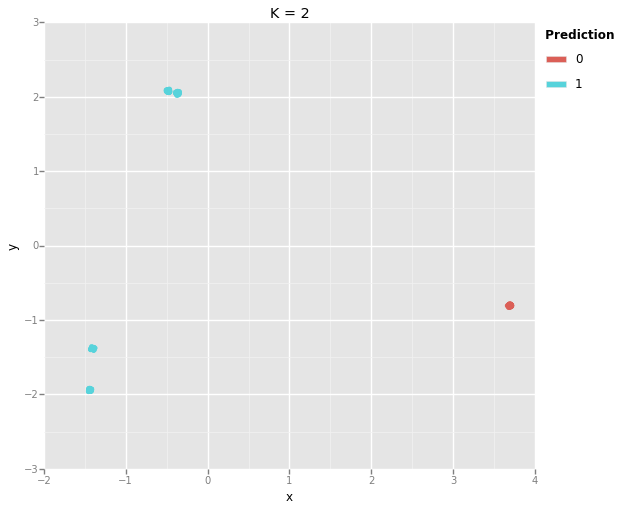

```python
(
    gg.ggplot(gg.aes(x="x", y="y", color="prediction"), data=ca1WithPredictionDF.toPandas()) +
    gg.geom_point() +
    gg.ggtitle("K = 2")
)
```

Matome, kad $K = 2$ tikrai nėra optimalus klasterių kiekis. $\mathbb{R}^2$ atveju galime nubraižyti sklaidos diagramą, tačiau ką daryti $\mathbb{R}^p$, kai $p > 2$ atveju? Vienas iš būdų yra apmokyti keletą modelių su skirtingomis $K$ reikšmėmis ir juos palyginti pagal iš anksto apsibrėžtų charakteristikų reikšmes.

Apmokome keletą modelių su skirtingomis $K$ reikšmėmis ir apskaičiuojame jų $S_K$ reikšmes.

```python
kValues = [2, 3, 4, 5, 6, 7]
models = [KMeans.train(featuresRDD, k=k) for k in kValues]
WSSSEs = [m.computeCost(featuresRDD) for m in models]

rowsWSSSSE = list(zip(kValues, map(float, WSSSEs)))
WSSSEDF = sc.parallelize(rowsWSSSSE).toDF(["K", "WSSSE"])
```

Aiškumo dėlei išvedame kiekvieno kintamojo reikšmes

```python
print("K reikšmės")
print(kValues)
print("\nModelių objektai")
print(models)
print("\nS_k reikšmės")
print(WSSSEs)
print("\nRezultatų eilutės su K ir S_k reikšmėmis")
print(rowsWSSSSE)
print("\npyspark.sql.DataFrame turinys su rezultatais")
WSSSEDF.show()
```

```
K reikšmės
[2, 3, 4, 5, 6, 7]

Modelių objektai
[<pyspark.mllib.clustering.KMeansModel object at 0xaaf33f6c>, <pyspark.mllib.clustering.KMeansModel object at 0xaaf3fd6c>, <pyspark.mllib.clustering.KMeansModel object at 0xaaf39b8c>, <pyspark.mllib.clustering.KMeansModel object at 0xaae7622c>, <pyspark.mllib.clustering.KMeansModel object at 0xaae64…

S_k reikšmės
[1697.8205877134912, 16.330327462684178, 0.7903686095224364, 0.10096064612601141, 0.09320600194790735, 0.0905808404608125]

Rezultatų eilutės su K ir S_k reikšmėmis
[(2, 1697.8205877134912), (3, 16.330327462684178), (4, 0.7903686095224364), (5, 0.10096064612601141), (6, 0.09320600194790735), (7, 0.0905808404608125)]

pyspark.sql.DataFrame turinys su rezultatais
+---+-------------------+
|  K|              WSSSE|
+---+-------------------+
|  2| 1697.8205877134912|
|  3| 16.330327462684178|
|  4| 0.7903686095224364|
|  5|0.10096064612601141|
|  6|0.09320600194790735|
|  7| 0.0905808404608125|
+---+-------------------+
```

Galime nubraižyti $S_K$ priklausomybės nuo $K$ grafiką.

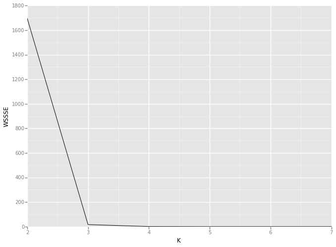

```python
gg.ggplot(gg.aes(x="K", y="WSSSE"), data=WSSSEDF.toPandas()) + gg.geom_line()
```

Aiškiai matome, kad $K = 2$ nėra optimali reikšmė.

Nubraižome grafiką su reikšmėmis $K > 2$

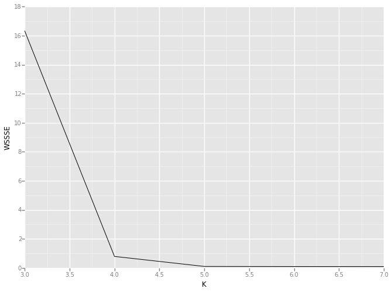

```python
gg.ggplot(gg.aes(x="K", y="WSSSE"), data=WSSSEDF.where(WSSSEDF["K"] > 2).toPandas()) + gg.geom_line()
```

Su $K = 4$ matomas ženklus pagerėjimas. $K=5$ taip pat suteikia pastebimą pagerėjimą. Sprendžiant tikrą uždavinį tokiu atveju interpretuotume klasterių centrus su $K = 4$ ir $K = 5$, tuomet parinktume prasmingesnę $K$ reikšmę.

$K = 4$ centrai

```python
models[kValues.index(4)].centers
```

```
[array([-0.42420425,  2.06439767]),
 array([-1.43806358, -1.94105892]),
 array([ 3.69629649, -0.80680897]),
 array([-1.40484502, -1.38455581])]
```

$K = 5$ centrai

```python
models[kValues.index(5)].centers
```

```
[array([-0.36754677,  2.04900384]),
 array([ 3.69629649, -0.80680897]),
 array([-1.43806358, -1.94105892]),
 array([-1.40484502, -1.38455581]),
 array([-0.48086173,  2.0797915 ])]
```

Tolesniam darbui galime sukurti funkciją, apmokančią keletą K-vidurkių modelių su nurodytomis $K$ reikšmėmis ir grąžinančią WSSSE reikšmę kiekvienai $K$ reikšmei. Joje patalpinsime jau naudotus teiginius (angl. *statement*). Patogumo dėlei panaudodami `collections.namedtuple` sukursime rezultatų klasę. `namedtuple` objektą galima naudoti ir kaip paprastą `tuple`, ir kaip objektą.

```python
import collections
```

```python
kmeansWSSSEResults = collections.namedtuple("KmeansWSSSEResults", ["ks", "WSSSEs", "models"])

def kmeansWSSSEsByK(featuresRDD, kValues):
    models = [KMeans.train(featuresRDD, k=k) for k in kValues]
    WSSSEs = [m.computeCost(featuresRDD) for m in models]
    return kmeansWSSSEResults(kValues, WSSSEs, models)
```

Rezultatų priskyrimas atskiriems kintamiesiems naudojant `tuple` „išpakavimą“ (angl. *tuple unpacking*):

```python
ks, wssses, models = kmeansWSSSEsByK(featuresRDD, [2, 3, 4, 5])
```

```python
print(ks, "\n")
print(wssses, "\n")
print(models, "\n")
```

```
[2, 3, 4, 5]

[1504.98682886255, 16.330327462684178, 0.7903686095224364, 0.10096064612601141]

[<pyspark.mllib.clustering.KMeansModel object at 0xaad9dbcc>, <pyspark.mllib.clustering.KMeansModel object at 0xaadd6dcc>, <pyspark.mllib.clustering.KMeansModel object at 0xaadea18c>, <pyspark.mllib.clustering.KMeansModel object at 0xaaf5cd6c>]
```

Rezultatų priskyrimas vienam kintamajam:

```python
results = kmeansWSSSEsByK(featuresRDD, [2, 3, 4, 5])
```

```python
print(results.ks, "\n")
print(results.WSSSEs, "\n")
print(results.models, "\n")
```

```
[2, 3, 4, 5]

[1504.98682886255, 16.330327462684178, 0.7903686095224364, 0.10096064612601141]

[<pyspark.mllib.clustering.KMeansModel object at 0xaadf66cc>, <pyspark.mllib.clustering.KMeansModel object at 0xaada514c>, <pyspark.mllib.clustering.KMeansModel object at 0xaadfff2c>, <pyspark.mllib.clustering.KMeansModel object at 0xaae01dac>]
```

Kadangi turime $\mathbb{R^2}$ duomenis, galime nubraižyti sklaidos diagramas su $K=4$ ir $K=5$

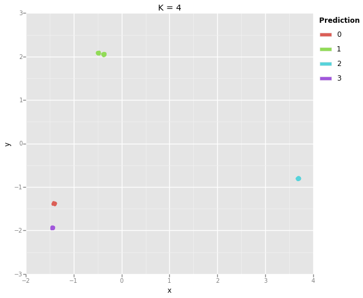

```python
ca1K4PredictionDF = (
    ca1DF.rdd.map(lambda row: addPredictionColumn(row, models[ks.index(4)], ["x", "y"]))
).toDF(ca1DF.columns + ["prediction"])

(
    gg.ggplot(gg.aes(x="x", y="y", color="prediction"), data=ca1K4PredictionDF.toPandas()) +
    gg.geom_point() +
    gg.ggtitle("K = 4")
)
```

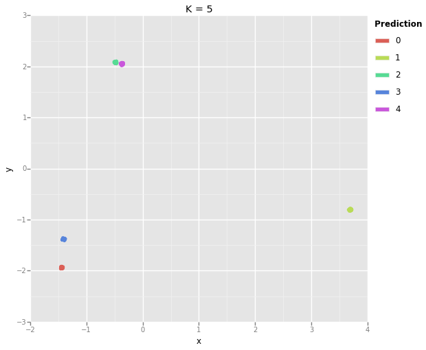

```python
ca1K5PredictionDF = (
    ca1DF.rdd.map(lambda row: addPredictionColumn(row, models[ks.index(5)], ["x", "y"]))
).toDF(ca1DF.columns + ["prediction"])

(
    gg.ggplot(gg.aes(x="x", y="y", color="prediction"), data=ca1K5PredictionDF.toPandas()) +
    gg.geom_point() +
    gg.ggtitle("K = 5")
)
```

## 2 pavyzdys

Kita iš galimų charakteristikų nustatyti optimalią $K$ reikšmę yra aprašyta [čia](http://www.ee.columbia.edu/~dpwe/papers/PhamDN05-kmeans.pdf) ir [čia](https://datasciencelab.wordpress.com/2014/01/21/selection-of-k-in-k-means-clustering-reloaded/). Jos reikšmė $f(K)$ apskaičiuojama tokiu būdu:

[figure not shown]

Optimilaus $K$ yra ties "alkūnine" $f(K)$ reikšme.

Pastebime, kad $\alpha_K$ yra rekurentinis sąryšis.

Pagal $f(K)$ išraišką matome, kad kiekvienam $K$ reikia turėti ir $S_{K-1}$ reišmes. Sukuriame reikalingas funkcijas.

```python
import collections
Pham2004Results = collections.namedtuple("Pham2004Results", ["ks", "fKs", "models"])

def computePham2004(featuresRDD, kValues):
    allKs = makeAllKs(kValues)
    _, WSSSEs, models = kmeansWSSSEsByK(featuresRDD, allKs)

    kToWSSSEMap = dict(zip(allKs, WSSSEs))
    kToModelMap = dict(zip(allKs, models))

    ksWithPairedWSSSEs = [
        (k, kToWSSSEMap[k], kToWSSSEMap.get(k - 1, 0),)
        for k in kValues]
    dimension = len(featuresRDD.first())

    fKs = [
        computeFK(k, Sk, prevSk, dimension)
        for (k, Sk, prevSk) in ksWithPairedWSSSEs]
    return Pham2004Results(kValues, fKs, [kToModelMap[k] for k in kValues])

def makeAllKs(initialKs):
    allKs = [k - 1 for k in initialKs if k - 1 > 0] + initialKs
    return sorted(list(set(allKs)))

def computeFK(k, SSE, prevSSE, dim):
    if k == 1 or prevSSE == 0:
        return 1
    weight = weightFactor(k, dim)
    return SSE / (weight * dim)

# calculating alpha_k in functional style with tail recursion -- which is not optimized in Python :(
def weightFactor(k, dim):
    if not k >= 2:
        raise ValueError("k should be greater than 1.")

    def weightFactorAccumulator(acc, k):
        if k == 2:
            return acc
        return weightFactorAccumulator(acc + (1 - acc) / 6, k - 1)

    k2Weight = 1 - 3 / (4 * dim)
    return weightFactorAccumulator(k2Weight, k)
```

$\alpha_K$ skaičiavome naudodami rekursiją (funkcija `weightFactor`). Deja, *Python* programavimo kalboje „uodegos rekursija“ (angl. *tail recursion*) [nėra optimizuota](http://kachayev.github.io/talks/uapycon2012/#/46) ir funkcija neveiks kai $K > 975$. Kai $K > 975$, *Python*'e $\alpha_K$ reikėtų skaičiuoti imperatyviai:

```python
def weightFactor(k, dim):
    if not k >= 2:
        raise ValueError("k must be greater than 1.")

    weight = 1 - 3 / (4 * dim)
    i = 2
    while i < k:
        weight_prev = weight
        weight = weight_prev + (1 - weight_prev) / 6
        i += 1
    return weight
```

Apskaičiuojame $f(K)$ statistikos reikšmes, kai $K \in \{1, 2, 3, 6, 9\}$:

```python
ks, fKs, _ = computePham2004(featuresRDD, [1, 2, 3, 6, 9])
print(ks)
print(fKs)
```

```
[1, 2, 3, 6, 9]
[1, 1358.256470170793, 11.876601791043038, 0.056877882920675374, 0.041480625207473816]
```

Sukuriame funkciją, kuri iš dviejų sąrašų ($K$ reikšmių ir $f(K)$ reikšmių) sukurs `pyspark.sql.DataFrame`:

```python
Pham2004Row = Row("K", "fK")

def makePham2004DF(ks, fKs):
    rowContents = list(zip(ks, fKs))
    return sc.parallelize(
        [Pham2004Row(k, float(fK))
         for (k, fK) in rowContents]).toDF()
```

```python
pham2004DF = makePham2004DF(ks, fKs)
pham2004DF.show()
```

```
+---+--------------------+
|  K|                  fK|
+---+--------------------+
|  1|                 1.0|
|  2|   1358.256470170793|
|  3|  11.876601791043038|
|  6|0.056877882920675374|
|  9|0.041480625207473816|
+---+--------------------+
```

Nubraižome $f(K)$ pagal $K$ grafiką.

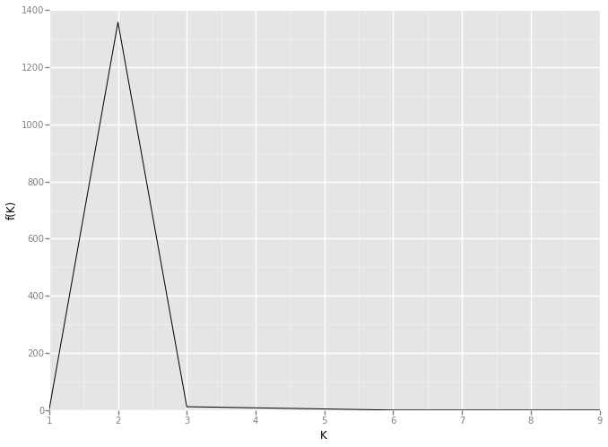

```python
gg.ggplot(gg.aes(x="K", y="fK"), data=pham2004DF.toPandas()) + gg.geom_line() + gg.ylab("f(K)")
```

Matome, kad „alkūnė“ yra kai $K = 3$, tačiau iš lentelės matome, kad $f(K)$ skirtumas tarp $K = 3$ ir $K = 6$ taip pat žymus. Taip galima matyti ir iš grafiku su $K >= 3$ reikšmėmis:

```python
pham2004DF.where(pham2004DF["K"] > 2).show()
```

```
+---+--------------------+
|  K|                  fK|
+---+--------------------+
|  3|  11.876601791043038|
|  6|0.056877882920675374|
|  9|0.041480625207473816|
+---+--------------------+
```

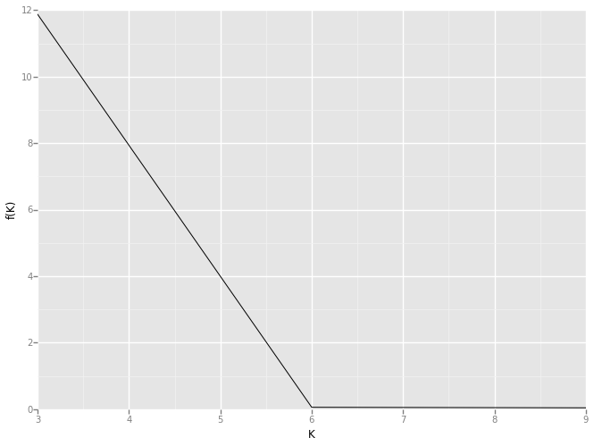

```python
gg.ggplot(gg.aes(x="K", y="fK"), data=pham2004DF.where(pham2004DF["K"] > 2).toPandas()) + gg.geom_line() + gg.ylab("f(K)")
```

Parinkime daugiau $K$ reikšmių itervale $[3; 9]$.

```python
moreKs = [3,4,5,6,7,8,9]

_, morefKs, moreModels = computePham2004(featuresRDD, moreKs)
pham2004moreKsDF = makePham2004DF(moreKs, morefKs)
pham2004moreKsDF.show()
```

```
+---+--------------------+
|  K|                  fK|
+---+--------------------+
|  3|  11.876601791043038|
|  4|  0.5343337078461542|
|  5|  0.0644715434241492|
|  6| 0.05691143667983206|
|  7| 0.05306118063734262|
|  8|0.050344477923907484|
|  9| 0.04203367442286244|
+---+--------------------+
```

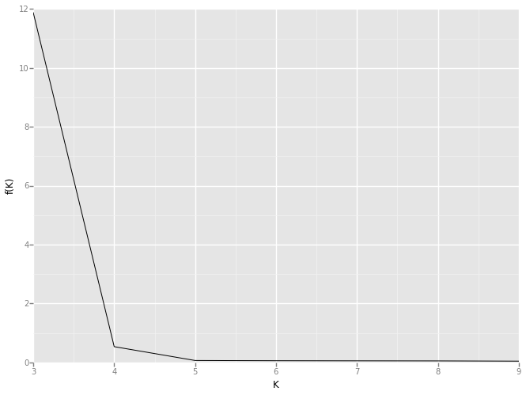

```python
gg.ggplot(gg.aes(x="K", y="fK"), data=pham2004moreKsDF.toPandas()) + gg.geom_line() + gg.ylab("f(K)")
```

Matome, kad „alkūninė“ reikšmė yra kai $K=4$, tačiau ir su $K=5$ turi matomas $k(K)$ sumažėjimas.

Nubraižome sklaidos diagramas šiems atvejams.

```python
kToModelMap = dict(zip(moreKs, moreModels))
kToModelMap
```

```
{3: <pyspark.mllib.clustering.KMeansModel at 0xaad54ecc>,
 4: <pyspark.mllib.clustering.KMeansModel at 0xaadec78c>,
 5: <pyspark.mllib.clustering.KMeansModel at 0xaadcdacc>,
 6: <pyspark.mllib.clustering.KMeansModel at 0xaaf67eac>,
 7: <pyspark.mllib.clustering.KMeansModel at 0xaadcacac>,
 8: <pyspark.mllib.clustering.KMeansModel at 0xaaf67e6c>,
 9: <pyspark.mllib.clustering.KMeansModel at 0xaadbda0c>}
```

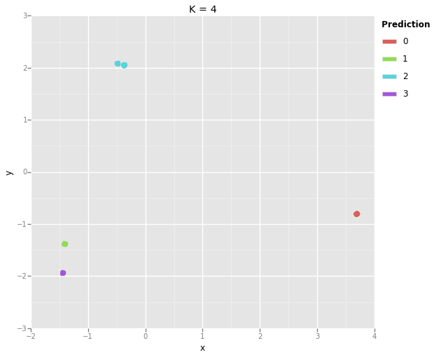

```python
ca1K4WithPredDF = (
    ca1DF.rdd.map(lambda row: addPredictionColumn(row, kToModelMap[4], ["x", "y"]))
).toDF(ca1DF.columns + ["prediction"])

gg.ggplot(gg.aes(x="x", y="y", color="prediction"), data=ca1K4WithPredDF.toPandas()) + gg.geom_point() + gg.ggtitle("K = 4")
```

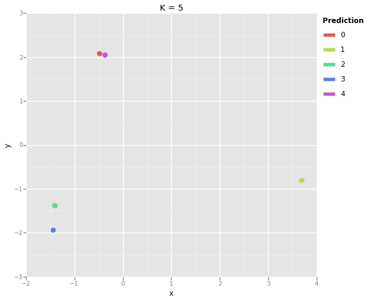

```python
ca1K5WithPredDF = (
    ca1DF.rdd.map(lambda row: addPredictionColumn(row, kToModelMap[5], ["x", "y"]))
).toDF(ca1DF.columns + ["prediction"])

gg.ggplot(gg.aes(x="x", y="y", color="prediction"), data=ca1K5WithPredDF.toPandas()) + gg.geom_point() + gg.ggtitle("K = 5")
```

## 3 Pavyzdys

Šį kartą naudosime `pyspark.ml` paketą. K-vidurkių modelių sudarymui naudosime [`pyspark.ml.clustering.Kmeans`](http://spark.apache.org/docs/latest/api/python/pyspark.ml.html#module-pyspark.ml.clustering), duomenų paruošimui naudosime [`pyspark.ml.feature.VectorAssembler`](http://spark.apache.org/docs/latest/api/python/pyspark.ml.html#pyspark.ml.feature.VectorAssembler) ir gausime [`pyspark.ml.PipelineModel`](http://spark.apache.org/docs/latest/api/python/pyspark.ml.html#pyspark.ml.PipelineModel) objektą, kuriuo galėsime atlikti prognozes iš pradinių duomenų.

Nuskaitome duomenų failą į `pyspark.sql.DataFrame`:

```python
ca1MlDF = (
    sqlContext.read.load("data/CA1.csv", format="com.databricks.spark.csv", header=True, inferSchema=True)
    .rdd.toDF(["id", "x", "y", "cluster"])
).cache()

ca1MlDF.show(5)
```

```
+---+------------+------------+-------+
| id|           x|           y|cluster|
+---+------------+------------+-------+
|  1|-0.485694686| 2.075174209|      1|
|  2|  -0.3682471| 2.037708135|      2|
|  3|-1.409078419|-1.371631094|      3|
|  4|-1.434896397|-1.959709476|      4|
|  5| 3.706690333|-0.803240913|      5|
+---+------------+------------+-------+
only showing top 5 rows
```

Sukuriame [`pyspark.ml.feature.VectorAssembler`](http://spark.apache.org/docs/latest/api/python/pyspark.ml.html#pyspark.ml.feature.VectorAssembler), kuriuo iš nurodytų stulpelių (`x` ir `y`) sukursime modeliui reikalingą vektorių stulpelį:

```python
from pyspark.ml.feature import VectorAssembler

vecAssembler = VectorAssembler(inputCols=["x", "y"], outputCol="features")
type(vecAssembler)
```

```
pyspark.ml.feature.VectorAssembler
```

Sukurtas `vecAssembler` objektas (kurio tipas yra `pyspark.ml.feature.VectorAssembler`) turi `transform` metodą, kuriuo iš stulpelių `x` ir `y` bus pagamintas vektorių stulpelis `features` ir iš jam perduodamo `DataFrame` objekto bus sukurtas naujas `DataFrame` su `features` stulpeliu:

```python
ca1mlFeaturizedDF = vecAssembler.transform(ca1MlDF)
ca1mlFeaturizedDF.show(5)
```

```
+---+------------+------------+-------+--------------------+
| id|           x|           y|cluster|            features|
+---+------------+------------+-------+--------------------+
|  1|-0.485694686| 2.075174209|      1|[-0.485694686,2.0...|
|  2|  -0.3682471| 2.037708135|      2|[-0.3682471,2.037...|
|  3|-1.409078419|-1.371631094|      3|[-1.409078419,-1....|
|  4|-1.434896397|-1.959709476|      4|[-1.434896397,-1....|
|  5| 3.706690333|-0.803240913|      5|[3.706690333,-0.8...|
+---+------------+------------+-------+--------------------+
only showing top 5 rows
```

Sukursime `pyspark.ml.clustering.KMeans` objektą (atminkime, kad 1 pavyzdyje naudojome `pyspark.mllib.clustering.KMeans`), kuriuo apmokysime `pyspark.ml.clustering.KMeansModel`. Duomenis pateiksime nebe `RDD`, o `DataFrame` objektu.

```python
from pyspark.ml.clustering import KMeans as MlKMeans

firstMlKMeans = MlKMeans(
    featuresCol="features", predictionCol="prediction", k=2,
    initMode="k-means||", maxIter=20)
type(firstMlKMeans)
```

```
pyspark.ml.clustering.KMeans
```

`pyspark.ml` paketo modelių klasės turi `explainParams` metodą, kuruo išvedami modelio parametrų paaiškinimai.

```python
print(firstMlKMeans.explainParams())
```

```
featuresCol: features column name (default: features, current: features)
initMode: the initialization algorithm. This can be either "random" to choose random points as initial cluster centers, or "k-means||" to use a parallel variant of k-means++ (default: k-means||, current: k-means||)
initSteps: steps for k-means initialization mode (default: 5)
k: number of clusters to create (default: 2, current: 2)
maxIter: max number of iterations (>= 0) (default: 20, current: 20)
predictionCol: prediction column name (default: prediction, current: prediction)
seed: random seed (default: -560949829)
tol: the convergence tolerance for iterative algorithms (default: 0.0001)
```

Apmokykime modelį.

```python
firstMlModel = firstMlKMeans.fit(ca1mlFeaturizedDF)
type(firstMlModel)
```

```
pyspark.ml.clustering.KMeansModel
```

```python
firstMlModel.clusterCenters()
```

```
[array([ 0.949296  ,  1.10732879]), array([-1.4214543 , -1.66280737])]
```

Sudarome `Pipeline` žingsnių seką iš `vecAssembler` ir `kmeans` komponentų.

```python
from pyspark.ml.pipeline import Pipeline

firstPipeline = Pipeline(stages=[vecAssembler, firstMlKMeans])
```

```python
firstPipelineModel = firstPipeline.fit(ca1MlDF)
```

```python
firstPipelineModel.transform(ca1MlDF).show(5)
```

```
+---+------------+------------+-------+--------------------+----------+
| id|           x|           y|cluster|            features|prediction|
+---+------------+------------+-------+--------------------+----------+
|  1|-0.485694686| 2.075174209|      1|[-0.485694686,2.0...|         0|
|  2|  -0.3682471| 2.037708135|      2|[-0.3682471,2.037...|         0|
|  3|-1.409078419|-1.371631094|      3|[-1.409078419,-1....|         1|
|  4|-1.434896397|-1.959709476|      4|[-1.434896397,-1....|         1|
|  5| 3.706690333|-0.803240913|      5|[3.706690333,-0.8...|         0|
+---+------------+------------+-------+--------------------+----------+
only showing top 5 rows
```

```python
MlKmeansWSSSEResults = collections.namedtuple("MlKmeansWSSSEResults", ["ks", "WSSSEs", "pipelineModels"])

def mlKmeansWSSSEsByK(initialDF, kValues):
    vecAssembler = VectorAssembler(inputCols=["x", "y"], outputCol="features")
    pipelineModels = [Pipeline(stages=[vecAssembler, MlKMeans(k=k)]).fit(initialDF)
                      for k in kValues]
    mlWSSSEs = [computeMlWSSSE(initialDF, pm) for pm in pipelineModels]
    return MlKmeansWSSSEResults(kValues, mlWSSSEs, pipelineModels)

def computeMlWSSSE(initialDF, pipelineModel):
    centers = pipelineModel.stages[-1].clusterCenters()
    predictionDF = pipelineModel.transform(initialDF)

    squaredDistancesRDD = predictionDF.rdd.map(
        lambda row: row.features.squared_distance(centers[row.prediction]))
    return squaredDistancesRDD.sum()
```

```python
computeMlWSSSE(ca1MlDF, firstPipelineModel)
```

```
1697.8205877134922
```

Naudosime $f(K)$ charakteristiką.

```python
MlPham2004Results = collections.namedtuple("Pham2004Results", ["ks", "fKs", "pipelineModels"])

def computeMlPham2004(initialDF, kValues):
    allKs = [k for k in makeAllKs(kValues) if k > 1]
    _, WSSSEs, pipelineModels = mlKmeansWSSSEsByK(initialDF, allKs)

    kToWSSSEMap = dict(zip(allKs, WSSSEs))
    kToPipelineModelMap = dict(zip(allKs, pipelineModels))

    ksWithPairedWSSSEs = [
        (k, kToWSSSEMap.get(k, 0), kToWSSSEMap.get(k - 1, 0),)
        for k in kValues]
    dimension = len(featuresRDD.first())

    fKs = [
        computeFK(k, Sk, prevSk, dimension)
        for (k, Sk, prevSk) in ksWithPairedWSSSEs]
    return Pham2004Results(kValues, fKs, [kToPipelineModelMap.get(k) for k in kValues])
```

```python
ks, fKs, pipelineModels = computeMlPham2004(ca1MlDF, [3, 4, 5, 6])
```

```python
rowsWSSSE = list(zip(ks, map(float, fKs)))
WSSSEDF = sc.parallelize(rowsWSSSE).toDF(["K", "fK"])
WSSSEDF.show()
```

```
+---+-------------------+
|  K|                 fK|
+---+-------------------+
|  3| 11.876601791043292|
|  4| 0.5343337078462461|
|  5|0.06447154342421324|
|  6|0.05631281990437413|
+---+-------------------+
```

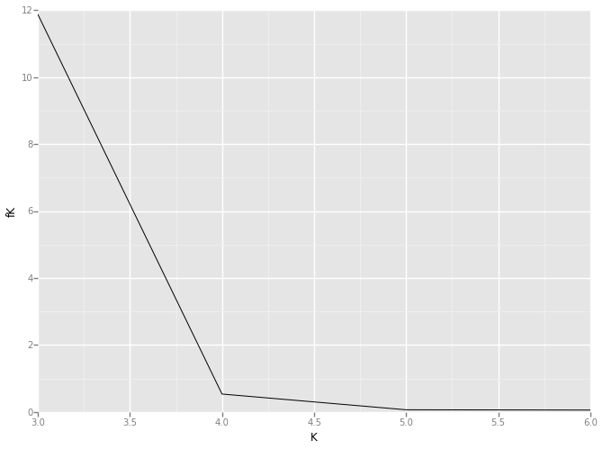

```python
gg.ggplot(gg.aes(x="K", y="fK"), data=WSSSEDF.toPandas()) + gg.geom_line()
```

## 3 pavyzdys

Šiame pavyzdyje naudosime `pyspark.ml` paketą, $S_k$ charakteristiką ir laikysime, kad neturime anksčiau rašyto kodo.

```python
ls data
```

```
CA10.xls  CA2.csv  CA4.xls  CA7.xls  CAB1.csv
CA1.csv   CA2.xls  CA5.xls  CA8.xls  CAB1.sas7bdat
CA1.xls   CA3.xls  CA6.xls  CA9.xls  Untitled.ipynb
```

```python
! in2csv data/CA2.xls > data/CA2.csv
```

```python
! head data/CA2.csv
```

```
id,X,y,klasteris
1,-0.543107008398867,-2.24589337158166,1
2,-3.05141284857379,-2.79020246961634,1
3,-2.63406157935159,-0.90642746845988,1
4,-2.94372086031095,-3.15672525023875,1
5,-1.59848537397944,-4.507897764527,1
6,-2.40908579499534,-4.51768121307842,1
7,-1.71876500225743,-5.25533798241366,1
8,-1.1705287055537,-2.10686355275734,1
9,-0.558161109901716,-3.90145324975195,1
```

```python
ca2DF = (
    sqlContext.read.load("data/CA2.csv", format="com.databricks.spark.csv", header=True, inferSchema=True)
    .rdd.toDF(["id", "x", "y", "cluster"])
)
```

```python
from pyspark.ml.clustering import KMeans as MlKMeans
from pyspark.ml.pipeline import Pipeline
from pyspark.ml.feature import VectorAssembler
import collections

MlKmeansWSSSEResults = collections.namedtuple("MlKmeansWSSSEResults", ["ks", "WSSSEs", "pipelineModels"])

vecAssembler = VectorAssembler(inputCols=["x", "y"], outputCol="features")

def mlKmeansWSSSEsByK(initialDF, kValues):
    pipelineModels = [Pipeline(stages=[vecAssembler, MlKMeans(k=k)]).fit(initialDF)
                      for k in kValues]
    mlWSSSEs = [computeMlWSSSE(initialDF, pm) for pm in pipelineModels]
    return MlKmeansWSSSEResults(kValues, mlWSSSEs, pipelineModels)

def computeMlWSSSE(initialDF, pipelineModel):
    centers = pipelineModel.stages[-1].clusterCenters()
    predictionDF = pipelineModel.transform(initialDF)

    squaredDistancesRDD = predictionDF.rdd.map(
        lambda row: row.features.squared_distance(centers[row.prediction]))
    return squaredDistancesRDD.sum()
```

```python
ca2ks, ca2WSSSEs, ca2PiplelineModels = mlKmeansWSSSEsByK(ca2DF, [2, 4, 6, 8])
```

```python
print(ca2ks)
print(ca2WSSSEs)
print(ca2PiplelineModels)
```

```
[2, 4, 6, 8]
[1001.7720986429694, 385.4731874592548, 288.5500188841973, 253.94386662825511]
[PipelineModel_4aa7a85163d2d72539b3, PipelineModel_4720aafdd99ca7ccf4a1, PipelineModel_4ebc85f2b21dd1f73246, PipelineModel_46d89a6593fc33a39a54]
```

```python
rowsCa2WSSSE = list(zip(ca2ks, map(float, ca2WSSSEs)))
rowsCa2WSSSE
```

```
[(2, 1001.7720986429694),
 (4, 385.4731874592548),
 (6, 288.5500188841973),
 (8, 253.9438666282551)]
```

```python
ca2WSSSEDF = sc.parallelize(rowsCa2WSSSE).toDF(["K", "WSSSE"])
ca2WSSSEDF.show()
```

```
+---+------------------+
|  K|             WSSSE|
+---+------------------+
|  2|1001.7720986429694|
|  4| 385.4731874592548|
|  6| 288.5500188841973|
|  8| 253.9438666282551|
+---+------------------+
```

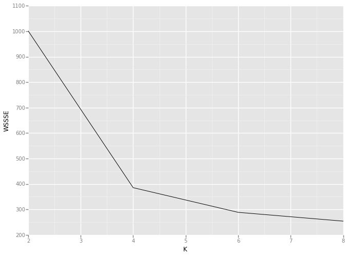

```python
gg.ggplot(gg.aes(x="K", y="WSSSE"), data=ca2WSSSEDF.toPandas()) + gg.geom_line()
```

```python
zoomedCa2ks, zoomedCa2WSSSEs, zoomedCa2PiplelineModels = mlKmeansWSSSEsByK(ca2DF, [3, 4, 5, 6])
zoomedWSSSEDF = sc.parallelize(list(zip(zoomedCa2ks, map(float, zoomedCa2WSSSEs)))).toDF(["K", "WSSSE"])
zoomedWSSSEDF.show()
```

```
+---+-----------------+
|  K|            WSSSE|
+---+-----------------+
|  3|688.6577702973373|
|  4|385.4731874592548|
|  5|330.3608106229127|
|  6|288.5500188841973|
+---+-----------------+
```

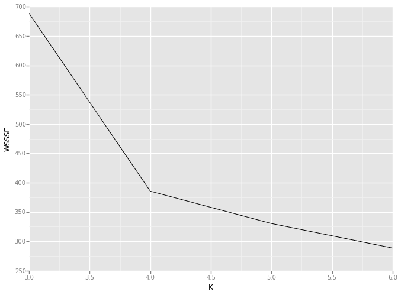

```python
gg.ggplot(gg.aes(x="K", y="WSSSE"), data=zoomedWSSSEDF.toPandas()) + gg.geom_line()
```

```python
kToPipelineModelMap = dict(zip(zoomedCa2ks, zoomedCa2PiplelineModels))
kToPipelineModelMap
```

```
{3: PipelineModel_4ed7b4d0dcd03b59b4db,
 4: PipelineModel_4edb95a638cc2890989e,
 5: PipelineModel_4257a8d99504bdd8e292,
 6: PipelineModel_4a5a81d73eff64c6117c}
```

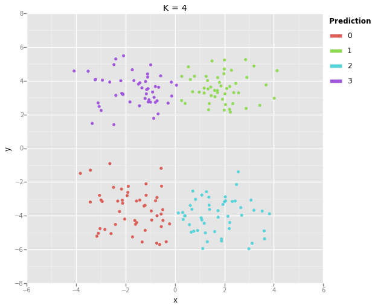

```python
K = 4
pipelineModel = kToPipelineModelMap[K]
transformedDF = pipelineModel.transform(ca2DF)
(
    gg.ggplot(gg.aes(x="x", y="y", color="prediction"), data=transformedDF.toPandas()) +
    gg.geom_point() +
    gg.ggtitle("K = {}".format(K))
)
```

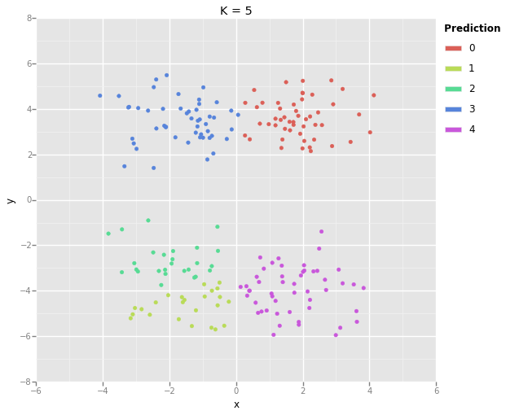

```python
K = 5
(
    gg.ggplot(gg.aes(x="x", y="y", color="prediction"),
              data=kToPipelineModelMap[K].transform(ca2DF).toPandas()) +
    gg.geom_point() +
    gg.ggtitle("K = {}".format(K))
)
```

## 4 Pavyzdys

Šiame pavyzdyje naudosime `pyspark.ml` paketą, tačiau rezultatų braižymui iškart sukursime `pandas.DataFrame`, o ne `pyspark.sql.DataFrame` objektą.

```python
! head data/CA2.csv
```

```
id,X,y,klasteris
1,-0.543107008398867,-2.24589337158166,1
2,-3.05141284857379,-2.79020246961634,1
3,-2.63406157935159,-0.90642746845988,1
4,-2.94372086031095,-3.15672525023875,1
5,-1.59848537397944,-4.507897764527,1
6,-2.40908579499534,-4.51768121307842,1
7,-1.71876500225743,-5.25533798241366,1
8,-1.1705287055537,-2.10686355275734,1
9,-0.558161109901716,-3.90145324975195,1
```

```python
csvFilename = "data/CA2.csv"

initialDF = (
    sqlContext.read.load(csvFilename, format="com.databricks.spark.csv", header=True, inferSchema=True)
    .rdd.toDF(["id", "x", "y", "cluster"])
)
```

```python
kValues = [3, 4, 5, 6, 7]
ks, WSSSEs, pipelineModels = mlKmeansWSSSEsByK(initialDF, kValues)
```

```python
rowsWSSSSE = list(zip(kValues, map(float, WSSSEs)))
rowsWSSSSE
```

```
[(3, 688.6577702973373),
 (4, 385.4731874592548),
 (5, 330.3608106229127),
 (6, 288.5500188841973),
 (7, 289.9752496140672)]
```

```python
import pandas as pd
```

```python
WSSSEPdDF = pd.DataFrame(rowsWSSSSE, columns=["K", "WSSSE"])
WSSSEPdDF
```

|  | K | WSSSE |
| --- | --- | --- |
| 0 | 3 | 688.657770 |
| 1 | 4 | 385.473187 |
| 2 | 5 | 330.360811 |
| 3 | 6 | 288.550019 |
| 4 | 7 | 289.975250 |

```python
import ggplot as gg
```

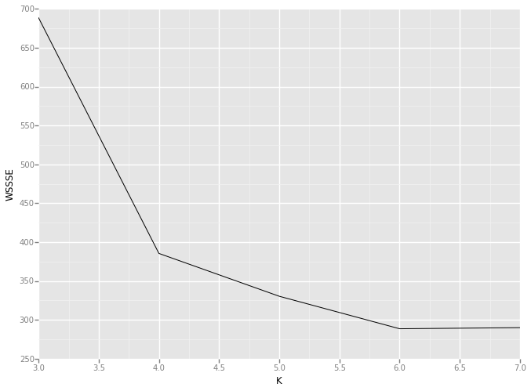

```python
%matplotlib inline
gg.ggplot(gg.aes(x="K", y="WSSSE"), data=WSSSEPdDF) + gg.geom_line()
```

```python
bestK = 4
bestPipelineModel = pipelineModels[kValues.index(bestK)]
```

```python
bestPipelineModel.stages[-1].clusterCenters()
```

```
[array([-1.73407565, -3.6239144 ]),
 array([ 1.87992979,  3.60856954]),
 array([ 1.72982544, -3.98276329]),
 array([-1.65629272,  3.46820048])]
```

```python
transformedDF = bestPipelineModel.transform(initialDF)
transformedDF.show(5)
```

```
+---+------------------+-----------------+-------+--------------------+----------+
| id|                 x|                y|cluster|            features|prediction|
+---+------------------+-----------------+-------+--------------------+----------+
|  1|-0.543107008398867|-2.24589337158166|      1|[-0.5431070083988...|         0|
|  2| -3.05141284857379|-2.79020246961634|      1|[-3.0514128485737...|         0|
|  3| -2.63406157935159|-0.90642746845988|      1|[-2.6340615793515...|         0|
|  4| -2.94372086031095|-3.15672525023875|      1|[-2.9437208603109...|         0|
|  5| -1.59848537397944|  -4.507897764527|      1|[-1.5984853739794...|         0|
+---+------------------+-----------------+-------+--------------------+----------+
only showing top 5 rows
```

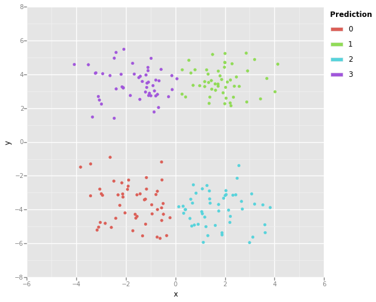

```python
%matplotlib inline
gg.ggplot(gg.aes(x="x", y="y", color="prediction"), data=transformedDF.toPandas()) + gg.geom_point()
```

## 5 pavyzdys

Šiame pavyzdyje laikysime, kad neturime anksčiau rašyto kodo, naudosime `pyspark.mllib` paketą, $S_k$ charakteristiką, tačiau rezultatų braižymui iškart sukursime `pandas.DataFrame`, o ne `pyspark.sql.DataFrame` objektą.

```python
csvFilename = "data/CA2.csv"

initialDF = (
    sqlContext.read.load(csvFilename, format="com.databricks.spark.csv", header=True, inferSchema=True)
    .rdd.toDF(["id", "x", "y", "cluster"])
)
```

```python
from pyspark.mllib.clustering import KMeans
from pyspark.mllib.linalg import DenseVector
import pandas as pd
import ggplot as gg

featuresRDD = initialDF.map(lambda r: DenseVector([r.x, r.y]))

kValues = [3, 4, 5, 6, 7]
models = [KMeans.train(featuresRDD, k=k) for k in kValues]
WSSSEs = [m.computeCost(featuresRDD) for m in models]

rowsWSSSSE = list(zip(kValues, map(float, WSSSEs)))
WSSSEPdDF = pd.DataFrame(rowsWSSSSE, columns=["K", "WSSSE"])
```

```python
WSSSEPdDF
```

|  | K | WSSSE |
| --- | --- | --- |
| 0 | 3 | 698.587516 |
| 1 | 4 | 385.473187 |
| 2 | 5 | 334.340187 |
| 3 | 6 | 296.593252 |
| 4 | 7 | 267.916980 |

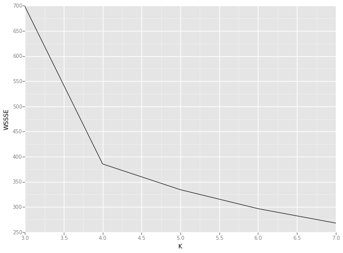

```python
%matplotlib inline
gg.ggplot(gg.aes(x="K", y="WSSSE"), data=WSSSEPdDF) + gg.geom_line()
```

```python
bestK = 4
bestModel = models[ks.index(bestK)]
```

```python
def addPredictionColumn(row, model, featureColumns):
    rowDict = row.asDict()
    features = DenseVector([rowDict[c] for c in featureColumns])
    predictedValue = model.predict(features)
    allValues = tuple(row) + (predictedValue,)
    return Row(*allValues)

pointsWithPredictionDF = (
    initialDF.rdd.map(lambda row: addPredictionColumn(row, bestModel, ["x", "y"]))
).toDF(initialDF.columns + ["prediction"])
```

```python
pointsWithPredictionDF.show()
```

```
+---+------------------+-----------------+-------+----------+
| id|                 x|                y|cluster|prediction|
+---+------------------+-----------------+-------+----------+
|  1|-0.543107008398867|-2.24589337158166|      1|         3|
|  2| -3.05141284857379|-2.79020246961634|      1|         3|
|  3| -2.63406157935159|-0.90642746845988|      1|         3|
|  4| -2.94372086031095|-3.15672525023875|      1|         3|
|  5| -1.59848537397944|  -4.507897764527|      1|         3|
|  6| -2.40908579499534|-4.51768121307842|      1|         3|
|  7| -1.71876500225743|-5.25533798241366|      1|         3|
|  8|  -1.1705287055537|-2.10686355275734|      1|         3|
|  9|-0.558161109901716|-3.90145324975195|      1|         3|
| 10|-0.956824174856276|-3.71709862009151|      1|         3|
| 11|-0.785013756890188|-3.10986166141838|      1|         3|
| 12| -1.20447746493601|-4.86513139962705|      1|         3|
| 13|-0.355319821655077|-5.54348852506407|      1|         3|
| 14|-0.553420587421398| -4.6460396220897|      1|         3|
| 15| -3.42202320076674|-1.30030824680577|      1|         3|
| 16| -1.62535863075391|-4.28349617225429|      1|         3|
| 17| -1.93446142767977|-2.80592873880717|      1|         3|
| 18| -3.82850489875886|-1.48680555806997|      1|         3|
| 19| -1.21068225982912|-3.38672021191178|      1|         3|
| 20| -3.03262936522136|-4.76395662156591|      1|         3|
+---+------------------+-----------------+-------+----------+
only showing top 20 rows
```

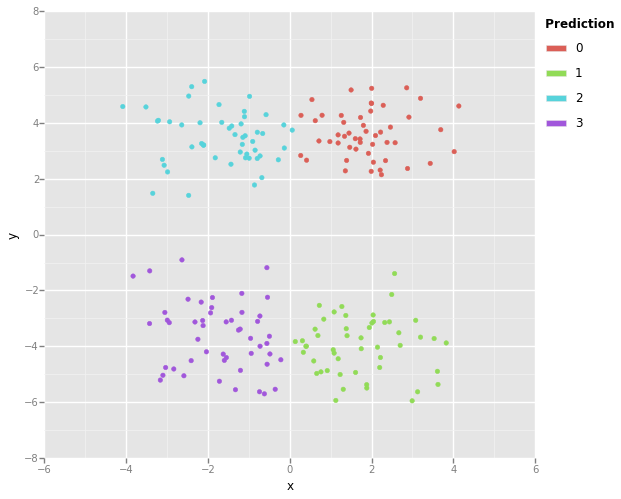

```python
%matplotlib inline
gg.ggplot(gg.aes(x="x", y="y", color="prediction"), data=pointsWithPredictionDF.toPandas()) + gg.geom_point()
```